# 8, 9, 10일차

## 분류(Classification) 모델

- 주어진 데이터를 클래스 별로 구별하는 과정
- Label의 개수에 따라 분류할 수 있음
- 이진 분류(binary)와 다중 분류(Multiclass)로 구분
- 알고리즘: Logistic Regression, Gradient Descent, Decision Tree

```python
# 출처: 포르투갈 남부 algarve 지역 호텔의 자산 관리 시스템(PMS)

import pandas as pd

df = pd.read_csv('test2.csv')
print(df.shape)
df.head().T
```

## Business Understanding

- 어떤 분야인가? 숙박업(호텔)
- 호텔의 수익구조나 Business Logic은? 예약을 받아서 checkin~checkout 서비스를 제공
- 어떻게 해야 수익이 많이 날까? 가능한 모든 객실이 full-booking
- 수익을 극대화 하려면? 수요량을 예측하고, 예약 취소 확률을 이용해서 over-booking을 관리
- 그렇다면 데이터셋에서 분석해야 할 것은? 예약 취소에 영향을 주는 요인을 찾아 경영에 반영할 수 있게 함
- 이와 유사한 분야는? 비행기 좌석 예약, 극장 예약, 렌탈

## Data Understanding

- Label: IsCanceled(예약 취소 여부)
- features: 나머지

## 경우의 수 column 처리

- 경우의 수를 숫자로 변환
- 경우의 수 처리법: Apply Domain Knowledge, Frequency Encoding, Target Encoding, One-hot Encoding

#### Apply Domain Knowledge

- 도메인 지식을 적용하는 방법
- 가장 이상적이고 우선적으로 적용
- 기준을 정했을 때 정도의 차이가 발생
- 순서를 매기면 의미가 있다

```python
set(df['Meal'])

# SC & Undefined: 식사 예약 안함
# BB: 조식 예약
# HB: 두 끼 예약
# FB: 세 끼 예약

# Meal 기준을 정했을 때 정도의 차이가 발생한가?
# 호텔 내부에서 식사 빈도수가 증가할수록 호텔 내부 체류시간과 소비 ↑
```

```python
mapper = {'SC       ': 0,
          'Undefined': 0,
          'BB       ': 1,
          'HB       ': 2,
          'FB       ': 3}

df['Day_Stay'] = df['Meal'].map(mapper)
df[['Meal', 'Day_Stay']].head(20).T
```

```python
len(set(df['Country']))
```

```python
df['Foreigner'] = 1
df.loc[df['Country'] == 'PRT', 'Foreigner'] = 0
interested = ['Foreigner', 'Country']
df[interested].head()

# Domain 내용을 참조해 의미있게 사용
```

#### Frequency Encoding

- 경우의 수를 빈도(%)로 변환, 각 경우의 수가 데이터셋에서 차지하는 비율 적용

```python
# normalize=True -> 전체를 1로 두고 비율을 구함
df['Country'].value_counts(normalize=True)

# PRT가 0.445247: 전체 row 중 Country의 PRT 데이터가 44.5% 차지
# 대략 50% 비율로 내국인(PRT)과 외국인으로 구분됨
```

```python
# Country, Country_Ratio 데이터 셋 생성
cr = pd.DataFrame(df['Country'].value_counts(normalize=True)).reset_index()
cr.columns = ['Country', 'Country_Ratio']
cr.head()
```

```python
df = pd.merge(df, cr)
df.head().T
```

```python
interested = ['Country', 'Country_Ratio']
df[interested].head()
```

#### Target Encoding

- label 정보를 경우의 수 별로 적용
- label이 있어야만 가능
- 선입견과 고정관념이 들어감 -> 과적합 될 확률이 높아짐

```python
df.columns
```

```python
import numpy as np

df.groupby('Country').agg({'IsCanceled': np.mean})

# Country가 AGO인 것들은 취소확률 29%
# Label이 들어가므로 선입견이 들어감
# ex) VNM, ZWE는 취소확률이 0% ?
```

```python
df.groupby('Country').agg({'IsCanceled': np.mean}).reset_index().sort_values(
    by='IsCanceled')

# 빈도수가 낮은 경우의 수는 고정관념과 선입견이 발생
# 빈도수가 높은 일반화의 경우에는 필요에 따라 고정관념과 선입견이 필요함
```

#### One-hot encoding

- 경우의 수 별로 column을 새로 만들어서 해당 경우의 수이면 1, 아니면 0
- 한 row에서 한 column만 hot(1) 함
- 일반적으로 도메인 지식을 적용할 수 없는 경우에 사용
- 경우의 수 column 처리의 FM

```python
pd.get_dummies(df['Meal'])
```

#### 다중 공선성(multi-colinearity)

- 일부 column이 다른 column과 상관 정도가 높아 부정적 영향을 미치는 현상
- 모든 경우의 수를 다 사용하지 않고 일부를 뺌

```python
pd.get_dummies(df['Country'])

# 경우의 수가 많으면 column 수가 많아짐 ->
# feature selection, 다중공선성 등을 고려해 해결해야 함
```

```python
# one-hot encoding 할 때, 경우의 수가 많은 경우 처리방안
len(set(df['Country']))
```

```python
df.columns
```

```python
sum(cr[:5]['Country_Ratio'])

# 방문 빈도가 높은 5개국 출신 손님이 전체 손님 중 80% 초과
```

```python
sum(cr[-100:]['Country_Ratio'])

# 방문 빈도가 낮은 100개국 출신 손님이 전체 손님 중 2% 수준
```

```python
top_5 = cr[:5]['Country'].values
top_5
```

```python
'KOR' in top_5
```

```python
def country_hot(country):
    if country in top_5:
        return country
    else:
        return 'other'
```

```python
sample = ['PRT', 'GBR', 'KOR', 'JPN']
for country in sample:
    print(country_hot(country))
```

```python
# apply 적용
df['Country_Simple'] = df['Country'].apply(lambda x : country_hot(x))
pd.get_dummies(df['Country_Simple'])

# 125 -> 6
```

```python
if x in top_5:
    return x
else:
    return 'other'
```

```python
x if x in top_5 else 'other'
```

```python
df['Country_Simple'] = df['Country'].apply(lambda x : x if x in top_5 else 'other')
pd.get_dummies(df['Country_Simple'])
```

```python
# Q1) 차를 가져오는 경우와 그렇지 않은 경우를 car_yes로 저장하세요.

df['car_yes'] = 0
df.loc[df['RequiredCarParkingSpaces'] > 0, 'car_yes'] = 1
set(df['car_yes'])
```

```python
# Q2) 고객이 예약한 객실과 고객에게 할당된 객실이 같을 때와 다를 때에 관한 정보를
#     추가하세요.
#     ex) 예약한 객실과 할당된 객실이 다른 경우는 몇 %일까?

#set(df['ReservedRoomType'])
set(df['AssignedRoomType'])
```

```python
df['ReservedRoomType'] = df['ReservedRoomType'].apply(lambda x : x[:1])
df['AssignedRoomType'] = df['AssignedRoomType'].apply(lambda x : x[:1])
set(df['ReservedRoomType'])
```

```python
df['RA'] = df['ReservedRoomType'] + df['AssignedRoomType']
df['RA_Changed'] = df['RA'].apply(lambda x : 0 if x[0] == x[1] else 1)
np.mean(df['RA_Changed'])

# 예약한 객실과 할당된 객실이 다른 경우: 대략 20%
```

```python
df.columns
```

```python
interested = ['IsCanceled', 'LeadTime', 'ArrivalDateYear', 'ArrivalDateMonth',
       'ArrivalDateWeekNumber', 'ArrivalDateDayOfMonth',
       'StaysInWeekendNights', 'StaysInWeekNights', 'Adults', 'Children',
       'Babies', 'Meal', 'Country', 'MarketSegment', 'DistributionChannel',
       'IsRepeatedGuest', 'PreviousCancellations',
       'PreviousBookingsNotCanceled', 'ReservedRoomType', 'AssignedRoomType',
       'BookingChanges', 'DepositType', 'Agent', 'Company',
       'DaysInWaitingList', 'CustomerType', 'ADR', 'RequiredCarParkingSpaces',
       'TotalOfSpecialRequests', 'ReservationStatus', 'ReservationStatusDate',
       'Day_Stay', 'Foreigner', 'Country_Ratio', 'Country_Simple', 'car_yes',
       'RA', 'RA_Changed']

df[interested].to_csv('test2_modify.csv', index=False)
```

```python
import pandas as pd

df = pd.read_csv('test2_modify.csv')
df.head().T
```

|  | 0 | 1 | 2 | 3 | 4 |
| --- | --- | --- | --- | --- | --- |
| IsCanceled | 0 | 0 | 0 | 0 | 1 |
| LeadTime | 342 | 737 | 0 | 9 | 85 |
| ArrivalDateYear | 2015 | 2015 | 2015 | 2015 | 2015 |
| ArrivalDateMonth | July | July | July | July | July |
| ArrivalDateWeekNumber | 27 | 27 | 27 | 27 | 27 |
| ArrivalDateDayOfMonth | 1 | 1 | 1 | 1 | 1 |
| StaysInWeekendNights | 0 | 0 | 0 | 0 | 0 |
| StaysInWeekNights | 0 | 0 | 2 | 2 | 3 |
| Adults | 2 | 2 | 2 | 2 | 2 |
| Children | 0 | 0 | 0 | 0 | 0 |
| Babies | 0 | 0 | 0 | 0 | 0 |
| Meal | BB | BB | BB | FB | BB |
| Country | PRT | PRT | PRT | PRT | PRT |
| MarketSegment | Direct | Direct | Direct | Direct | Online TA |
| DistributionChannel | Direct | Direct | Direct | Direct | TA/TO |
| IsRepeatedGuest | 0 | 0 | 0 | 0 | 0 |
| PreviousCancellations | 0 | 0 | 0 | 0 | 0 |
| PreviousBookingsNotCanceled | 0 | 0 | 0 | 0 | 0 |
| ReservedRoomType | C | C | C | C | A |
| AssignedRoomType | C | C | C | C | A |
| BookingChanges | 3 | 4 | 0 | 0 | 0 |
| DepositType | No Deposit | No Deposit | No Deposit | No Deposit | No Deposit |
| Agent | NULL | NULL | NULL | 303 | 240 |
| Company | NULL | NULL | NULL | NULL | NULL |
| DaysInWaitingList | 0 | 0 | 0 | 0 | 0 |
| CustomerType | Transient | Transient | Transient | Transient | Transient |
| ADR | 0.0 | 0.0 | 107.0 | 103.0 | 82.0 |
| RequiredCarParkingSpaces | 0 | 0 | 0 | 0 | 0 |
| TotalOfSpecialRequests | 0 | 0 | 0 | 1 | 1 |
| ReservationStatus | Check-Out | Check-Out | Check-Out | Check-Out | Canceled |
| ReservationStatusDate | 2015-07-01 | 2015-07-01 | 2015-07-03 | 2015-07-03 | 2015-05-06 |
| Day_Stay | 1 | 1 | 1 | 3 | 1 |
| Foreigner | 0 | 0 | 0 | 0 | 0 |
| Country_Ratio | 0.445247 | 0.445247 | 0.445247 | 0.445247 | 0.445247 |
| Country_Simple | PRT | PRT | PRT | PRT | PRT |
| car_yes | 0 | 0 | 0 | 0 | 0 |
| RA | CC | CC | CC | CC | AA |
| RA_Changed | 0 | 0 | 0 | 0 | 0 |

## EDA

- 그래프를 그리기 위해 column 골라야 함

```python
df.describe().columns
```

```
Index(['IsCanceled', 'LeadTime', 'ArrivalDateYear', 'ArrivalDateWeekNumber',
       'ArrivalDateDayOfMonth', 'StaysInWeekendNights', 'StaysInWeekNights',
       'Adults', 'Children', 'Babies', 'IsRepeatedGuest',
       'PreviousCancellations', 'PreviousBookingsNotCanceled',
       'BookingChanges', 'DaysInWaitingList', 'ADR',
       'RequiredCarParkingSpaces', 'TotalOfSpecialRequests', 'Day_Stay',
       'Foreigner', 'Country_Ratio', 'car_yes', 'RA_Changed'],
      dtype='object')
```

```python
label = 'IsCanceled'
features = ['LeadTime', 'ArrivalDateYear', 'ArrivalDateWeekNumber',
       'ArrivalDateDayOfMonth', 'StaysInWeekendNights', 'StaysInWeekNights',
       'Adults', 'Children', 'Babies', 'IsRepeatedGuest',
       'PreviousCancellations', 'PreviousBookingsNotCanceled',
       'BookingChanges', 'DaysInWaitingList', 'ADR',
       'TotalOfSpecialRequests', 'Day_Stay',
       'Foreigner', 'Country_Ratio', 'car_yes', 'RA_Changed']

X, y = df[features], df[label]

# column 수가 많음 -> 경우의 수를 줄이는데 중점 -> embed 방식 활용
```

```python
# 영향력이 가장 높은 것은?

# 1. module import
from sklearn.ensemble import RandomForestClassifier as rf

# 2. model 생성, 학습
model = rf()
model.fit(X, y)

# 3. .feature_importances_
imp = pd.DataFrame()
imp['features'] = features
imp['importance'] = model.feature_importances_

# 4. 정렬
imp.sort_values(by='importance', ascending=False).head(5)
```

|  | features | importance |
| --- | --- | --- |
| 0 | LeadTime | 0.183132 |
| 14 | ADR | 0.129723 |
| 2 | ArrivalDateWeekNumber | 0.082692 |
| 18 | Country_Ratio | 0.081207 |
| 3 | ArrivalDateDayOfMonth | 0.074429 |

```python
import numpy as np

tgt = df.groupby('LeadTime').agg({label: np.mean}).reset_index()
tgt

# LeadTime이 0이면 당일날 예약, 1이면 하루전 예약, ...
```

|  | LeadTime | IsCanceled |
| --- | --- | --- |
| 0 | 0 | 0.048366 |
| 1 | 1 | 0.056172 |
| 2 | 2 | 0.092920 |
| 3 | 3 | 0.079487 |
| 4 | 4 | 0.063566 |
| ... | ... | ... |
| 407 | 471 | 1.000000 |
| 408 | 532 | 0.000000 |
| 409 | 542 | 0.000000 |
| 410 | 709 | 0.000000 |
| 411 | 737 | 0.000000 |

412 rows × 2 columns

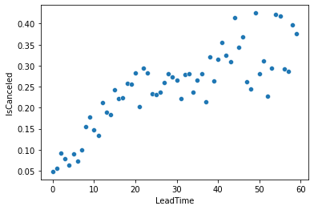

```python
import seaborn as sns

tgt = tgt.loc[tgt['LeadTime'] < 60]
sns.scatterplot(data=tgt, x='LeadTime', y='IsCanceled')

# 일주일 전에 예약한 고객은 예약 취소율이 낮음
# LeadTime이 늘어날수록 취소율이 높아짐(LeadTime이 적은 구간에서 선형성을 지님)
# 20~40일 예약한 고객은 20~30% 정도 취소율을 보임
# 50일 이후부터는 취소율이 다양함
```

```python
hue = 'Foreigner'
df.groupby(['LeadTime', hue]).agg({label: np.mean})
```

| LeadTime | Foreigner | IsCanceled |
| --- | --- | --- |
| 0 | 0 | 0.065923 |
|  | 1 | 0.018261 |
| 1 | 0 | 0.075975 |
|  | 1 | 0.021544 |
| 2 | 0 | 0.114530 |
| ... | ... | ... |
| 471 | 0 | 1.000000 |
| 532 | 1 | 0.000000 |
| 542 | 1 | 0.000000 |
| 709 | 1 | 0.000000 |
| 737 | 0 | 0.000000 |

786 rows × 1 columns

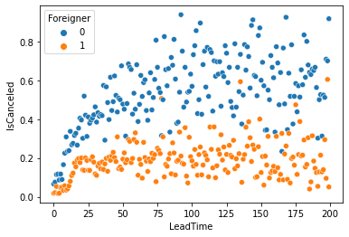

```python
tgt = df.groupby(['LeadTime', hue]).agg({label: np.mean}).reset_index()
tgt = tgt.loc[tgt['LeadTime'] < 200]
sns.scatterplot(data=tgt, x='LeadTime', y='IsCanceled', hue=hue)

# 외국인은 내국인 대비 예약 취소율이 낮음
```

```python
df.columns
```

```
Index(['IsCanceled', 'LeadTime', 'ArrivalDateYear', 'ArrivalDateMonth',
       'ArrivalDateWeekNumber', 'ArrivalDateDayOfMonth',
       'StaysInWeekendNights', 'StaysInWeekNights', 'Adults', 'Children',
       'Babies', 'Meal', 'Country', 'MarketSegment', 'DistributionChannel',
       'IsRepeatedGuest', 'PreviousCancellations',
       'PreviousBookingsNotCanceled', 'ReservedRoomType', 'AssignedRoomType',
       'BookingChanges', 'DepositType', 'Agent', 'Company',
       'DaysInWaitingList', 'CustomerType', 'ADR', 'RequiredCarParkingSpaces',
       'TotalOfSpecialRequests', 'ReservationStatus', 'ReservationStatusDate',
       'Day_Stay', 'Foreigner', 'Country_Ratio', 'Country_Simple', 'car_yes',
       'RA', 'RA_Changed'],
      dtype='object')
```

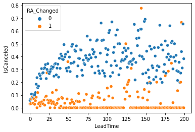

```python
hue = 'RA_Changed'
tgt = df.groupby(['LeadTime', hue]).agg({label: np.mean}).reset_index()
tgt = tgt.loc[tgt['LeadTime'] < 200]
sns.scatterplot(data=tgt, x='LeadTime', y='IsCanceled', hue=hue)
```

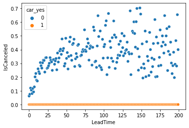

```python
hue = 'car_yes'
tgt = df.groupby(['LeadTime', hue]).agg({label: np.mean}).reset_index()
tgt = tgt.loc[tgt['LeadTime'] < 200]
sns.scatterplot(data=tgt, x='LeadTime', y='IsCanceled', hue=hue)
```

```python
# Q) 어떤 경로로 예약했는지에 대한 column을 기반으로 의미있는 문장을 도출하세요.

set(df['MarketSegment'])
```

```
{'Complementary',
 'Corporate',
 'Direct',
 'Groups',
 'Offline TA/TO',
 'Online TA'}
```

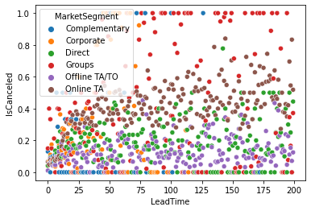

```python
hue = 'MarketSegment'
tgt = df.groupby(['LeadTime', hue]).agg({label: np.mean}).reset_index()
tgt = tgt.loc[tgt['LeadTime'] < 200]
sns.scatterplot(data=tgt, x='LeadTime', y='IsCanceled', hue=hue)

# online으로 예약한 경우 offline 예약 대비 취소율 ↑
```

## Data Preparation

```python
# train, test split
train, test = df[0::2], df[1::2]
train, test = train.reset_index(), test.reset_index()

X_train, y_train = train[features], train[label]
X_test, y_test = test[features], test[label]
```

## Modeling

- Tree 구조 알고리즘을 이용해 내부가 어떻게 생겼는지 파악

```python
from sklearn.tree import DecisionTreeClassifier as dt
from sklearn.tree import export_graphviz as eg

model = dt(max_depth=5)
model.fit(X_train, y_train)

eg(model, out_file='tree.txt', feature_names=features,
   class_names=['cancel_no', 'cancel_yes'])
```

#### 지니계수 계산방식

- 불순도를 확인
- 특정 사건이 일어날 확률을 yes_prob, 일어나지 않을 확률을 no_prob
- yes_prob * (1 - yes_prob) --> A라 하고,
- no_prob * (1 - no_prob) --> B라 한다면,
- A + B가 지니계수임

```python
size = 8815
yes_prob = 3726 / size
no_prob = 5089 / size
A = yes_prob * (1 - yes_prob)
B = no_prob * (1 - no_prob)
print(A + B)
```

```
0.4880458945443443
```

```python
yes_prob = 0.0
no_prob = 1
A = yes_prob * (1 - yes_prob)
B = no_prob * (1 - no_prob)
print(A + B)
```

```
0.0
```

## 알고리즘 구분용 용어

- ensemble: 정형 데이터를 다루는데 가장 뛰어는 성과를 내는 알고리즘, Random Forest, Extra Tree, Gradient Boosting
- bagging: bootstrap으로 추출된 값들의 통계량을 계산
- boosting: 오답을 이용해 점수 상승을 도모

#### bagging

- bootstrap: 데이터셋의 row를 무작위로 복원추출하여 새로운 데이터셋을 생성
- bootstrap을 이용하면 새로운 데이터셋을 만들 때마다 row의 구성이 좀 씩 달라짐
- 서로 조금씩 다른 데이터셋을 n개 만들고, n개의 데이터셋에 대해 학습을 진행
- n개의 학습된 예측결과를 합산

#### boosting

- 이전 모델의 오차를 보완하는 방향으로 만들어짐
- 오답을 이용해 점수 상승을 도모, 오답을 새로운 정보로 이용하는 접근법 통칭
- 학습 후 문제를 풀고, 못 맞추는 정보를 새로운 정보로 이용
- 첫 번째 알고리즘으로 학습하고 예측하여 못 맞춘 정도(오차) 정보 획득 -> 오차를 두 번째 알고리즘의 label로 사용(n번째 알고리즘은 n-1번째 알고리즘의 오차를 label로 학습)
- 첫 번째 알고리즘이 얼마나 틀렸는지 두 번째 알고리즘이 공부하는 개념
- 정형 데이터 기준으로 가장 정확도가 높은 알고리즘(**잘 사용했을 때**)

#### GBDT(Gradient Boosted Decision Tree)

- 결정 트리를 사용해 이전 트리의 오차를 보완하는 방식으로 경사 하강법을 사용해 ensemble 하는 방법
- ex) XGBoost, CatBoost, LightGBM
- bagging은 병렬 처리가 가능하지만 boosting은 병렬 처리가 안됨
- XGBoost는 기존 boosting의 문제점을 보완해 병렬 처리가 어느정도 가능하게 함

#### boosting 계열 알고리즘의 단점

- 속도가 느림
- 과적합 쉽게 발생
- 대충 사용하면 다른 알고리즘보다 성능이 안좋음 -> Tunning

## 분류 문제의 평가지표

- 회귀 문제에서는 숫자의 크기를 이용해 틀림의 정도를 나타냄 -> 분류 문제에서는 사용 x
- 혼동행렬 개념 도입

```python
import pandas as pd
from sklearn.tree import DecisionTreeClassifier as dt

df = pd.read_csv('test2_modify.csv')

label = 'IsCanceled'
features = ['LeadTime', 'ArrivalDateYear', 'ArrivalDateWeekNumber',
       'ArrivalDateDayOfMonth', 'StaysInWeekendNights', 'StaysInWeekNights',
       'Adults', 'Children', 'Babies', 'IsRepeatedGuest',
       'PreviousCancellations', 'PreviousBookingsNotCanceled',
       'BookingChanges', 'DaysInWaitingList', 'ADR',
       'TotalOfSpecialRequests', 'Day_Stay',
       'Foreigner', 'Country_Ratio', 'car_yes', 'RA_Changed']

train, test = df[0::2], df[1::2]
train, test = train.reset_index(), test.reset_index()

X_train, y_train = train[features], train[label]
X_test, y_test = test[features], test[label]

model = dt(max_depth=5)
model.fit(X_train, y_train)
```

```
DecisionTreeClassifier(max_depth=5)
```

```python
# 예측값
model.predict(X_test)
```

```
array([0, 0, 1, ..., 0, 0, 0], dtype=int64)
```

```python
# 실제값
y_test
```

```
0        0
1        0
2        1
3        0
4        0
        ..
19793    0
19794    0
19795    0
19796    0
19797    0
Name: IsCanceled, Length: 19798, dtype: int64
```

```python
for_plot = pd.DataFrame()
for_plot['predict'] = model.predict(X_test)
for_plot['actual'] = y_test
for_plot
```

|  | predict | actual |
| --- | --- | --- |
| 0 | 0 | 0 |
| 1 | 0 | 0 |
| 2 | 1 | 1 |
| 3 | 1 | 0 |
| 4 | 1 | 0 |
| ... | ... | ... |
| 19793 | 0 | 0 |
| 19794 | 0 | 0 |
| 19795 | 0 | 0 |
| 19796 | 0 | 0 |
| 19797 | 0 | 0 |

19798 rows × 2 columns

## 자주 사용하는 분류 문제의 평가지표

1. accuracy
- acc = (TP + TN) / (TP + TN + FN + FP)